# Permit Cleaning Data

### Intro

This file is complied by Andrew D. Smith for use by the WUMCRC. Project started on 3/29/2019

## Dependencies and library

```r
library(dplyr)
library(RODBC)
library(rgdal)
library(maptools)
library(tidyverse)
library(sp)
library(sf)
library(ggplot2)
library(ggmap)
```

### set wd

```r
setwd("G:/Projects/Monthly-Reports/stl-building-permits/permit-data-cleaning")
```

### import data

```r
channel <- odbcDriverConnect("Driver={Microsoft Access Driver (*.mdb, *.accdb)};DBQ=G:/Projects/Monthly-Reports/stl-building-permits/permit-data-cleaning/prmbdo/prmbdo")


#Use odbcDriverConnect instead? odbcConnnectAccess only works on 32-bit#
```

### Run SQL Query to return data

```r
data <- sqlQuery( channel , paste ("select *
 from PrmBldg"))
```

#Cleaning Data

### filter only recent permits

For this next line, you will need to change the date. The dates are in the format ‘YYYY-MM-DD’. For this code we are filtering out only data from December 2019.

```r
data_month <- filter(data, FirstDate > '2019-12-01'& FirstDate < '2020-01-01')
```

### drop unused variables

This code chunk uses the `select` function to select only variables we wish to be in our new data frame, `data_month`

```r
data_month<- select(data_month, AppType, CancelType, CityBlock, Parcel, OwnerCode, Handle, AddrNum, StDir,
       StName, StType, UnitNum, OrigAddress, ProjectType, MainStrucType, AppDate, IssueDate,
       CompleteDate, CancelDate, EstProjectCost, AppDescription, StrucType1, StrucType2,
       NbrOfUnits, NewUse, NewUseGroup1, NewUseGroup2, NewUseGroup3, OldUse, OwnerName,
       OwnerCo, OwnerAddr, OwnerCity, OwnerState, OwnerZIP, GeoCityBLockPart, Ward10,
       Ward00, Nbrhd, FirstDate, LastDate, UpDateGeo)
```

### Filter Out Permits without a Cancellation Date

Use the filter command to filter out only missing values (using `is.na`) in the `CancelDate` variable. This will in turn remove any permits that have a cancellation date from the data frame `data_month`.

```r
data_month%>%
  filter(is.na(CancelDate)) -> data_month
```

### Filter by Neighborhood

This code chunk uses the filter command to filter out only neighborhoods that we are interested in studying. This filters out the 10 neighborhoods in the `Nbrhd` variable that we want to study.

```r
data_month <- filter(data_month, Nbrhd %in% c("38", "39", "46", "47", "48", "49", "51", "53", "54", "58"))
```

### Recode values to neighborhood names

This code chunk creates a new variable called `nbhd_name` that contains the names of the neighborhoods based on their `Nbrhd` number. We use an `ifelse(grepl)` statement which says that if we find the first argument in the `Nbrhd` variable to be TRUE then it returns a specified value (in this case the actual neighborhood name) in our new variable that we specified in our `mutate` function, `nbhd_name`.

```r
data_month <- mutate(data_month, nbhd_name = ifelse(grepl("38", Nbrhd), "Central West End",
                                             ifelse(grepl("39", Nbrhd), "Forest Park South East",
                                             ifelse(grepl("46", Nbrhd), "Skinker DeBaliviere",
                                             ifelse(grepl("47", Nbrhd), "DeBaliviere Place",
                                             ifelse(grepl("48", Nbrhd), "West End",
                                             ifelse(grepl("49", Nbrhd), "Visitation Park",
                                             ifelse(grepl("51", Nbrhd), "Academy",
                                             ifelse(grepl("53", Nbrhd), "Fountain Park",
                                             ifelse(grepl("54", Nbrhd), "Lewis Place",
                                             ifelse(grepl("58", Nbrhd), "Vandeventer", NA)))))))))))
```

### Recode `NewUse` Variable

This code chunk mutates the `NewUse` variable to the new `new_use` variable which displays either Residential, Comercial, Institutional, or Industrial new use of the property. Just like our previous code chunk, this code uses an `ifelse(grepl)` statement within the mutate function to return a specified value if the first argument is true.

```r
data_month <- mutate(data_month, new_use = ifelse(grepl("R2", NewUseGroup1), "Residential",
                                             ifelse(grepl("R3", NewUseGroup1), "Residential",
                                             ifelse(grepl("R1", NewUseGroup1), "Commercial",
                                             ifelse(grepl("B", NewUseGroup1), "Institutional",
                                             ifelse(grepl("M", NewUseGroup1), "Commercial",
                                             ifelse(grepl("E", NewUseGroup1), "Institutional",
                                             ifelse(grepl("I2", NewUseGroup1), "Institutional",
                                             ifelse(grepl("U", NewUseGroup1), "Commercial",
                                             ifelse(grepl("RESTAURANT", NewUse), "Commercial",
                                             ifelse(grepl("COMM/RESIDENT", NewUse), "Residential",
                                             ifelse(grepl("EVENT SPACE", NewUse), "Commercial",
                                             ifelse(grepl("CHURCH", NewUse), "Institutional",
                                             ifelse(grepl("WAREHOUSE", NewUse), "Industrial",
                                             ifelse(grepl("PARKING GARAGE", NewUse), "Commercial",
                                             ifelse(grepl("PARKING LOT", NewUse), "Commercial", NA))))))))))))))))
```

#Descriptive Statistics

### `EstProjectCost` Total

This code returns the average project cost by using the `mean` function.

```r
mean(data_month$EstProjectCost)
```

```
[1] 403979.7
```

This code uses the `table` function to return how many permits are being used in each neighborhood.

```r
table(data_month$nbhd_name)
```

```
               Academy       Central West End      DeBaliviere Place Forest Park South East
                     3                     49                      4                     15
         Fountain Park    Skinker DeBaliviere            Vandeventer               West End
                     1                      8                      2                     11
```

###Average Project Cost by `new_use`

This code chunk calculates the mean `EstProjectCost` by `new_use` variable. You can also use a `by()` command for this and get the same result.

```r
sapply(split(data_month$EstProjectCost, data_month$new_use), mean)
```

```
   Commercial    Industrial Institutional   Residential
   2261796.38    4500000.00     477614.00      65420.02
```

### Average Building Permit Cost by `nbhd_name`

This code chunk uses a `by()` command to give us the mean of `EstProjectCost` by `nbhd_name`

```r
by(data_month$EstProjectCost, list(data_month$nbhd_name), mean)
```

```
: Academy
[1] 79500
------------------------------------------------------------------------------------
: Central West End
[1] 502179.2
------------------------------------------------------------------------------------
: DeBaliviere Place
[1] 61685
------------------------------------------------------------------------------------
: Forest Park South East
[1] 704826.9
------------------------------------------------------------------------------------
: Fountain Park
[1] 50000
------------------------------------------------------------------------------------
: Skinker DeBaliviere
[1] 26375
------------------------------------------------------------------------------------
: Vandeventer
[1] 61250
------------------------------------------------------------------------------------
: West End
[1] 138380.6
```

### Create New Variable for Building Permits Greater Than 50,000

This code uses the `mutate` function to create 2 variables. One, `big_cost`, for building permitst that are greater than or equal to and `EstProjectCost` of 50,000. It returns a value of 1 if it is true and a NA value if it is false. The same thing is done for the newly created variable `lil_cost` which is for building permits less than 50,000.

```r
data_month <- mutate(data_month, big_cost = ifelse(EstProjectCost >= 50000, 1, NA))
data_month <- mutate(data_month, lil_cost = ifelse(EstProjectCost < 50000, 1, NA))
```

### Create Variable `count` of Building Permits By `nbhd_name` and `new_use`

This code uses the `group_by` function to group `nbhd_name` and `new_use` variables and then a `mutate` function to create a new varialbe `count` that calculates how many building permits are in each neighborhood by new use.

```r
data_month%>%
  group_by(nbhd_name, new_use)%>%
  mutate(count = n()) -> data_month
```

### Create New Dataset `means`

This code creates a new dataset called `means` that contains a breakdown of building permits by neighborhood broken up by `new_use`. The new dataset contains the `mean` variable which is the mean `EstProjectCost`, a `count1` variable which is simply the number of building permits, a `high_cost` variable which is the number of housing permits whose `EstProjectCost` is greater than or equal to 50,000, and a `low_cost` varaiable which is the number of housing permits whose `EstProjectCost` is less than 50,000.

The code uses the `group_by` function to group `nbhd_name` and `new_use` variables and then a `summarise` function to create an output of one row for each group. within this function the variables above are created using `mean` and `sum` functions.

```r
data_month %>%
  group_by(nbhd_name, new_use) %>%
  summarise(mean = mean(EstProjectCost), count1 = mean(count), high_cost = sum(big_cost, na.rm = TRUE), low_cost = sum(lil_cost, na.rm = TRUE)) -> means
```

#Visual analysis

### Basic Graphs

This code chunk creates a bar plot that displays the number of building permits per each neighborhood.

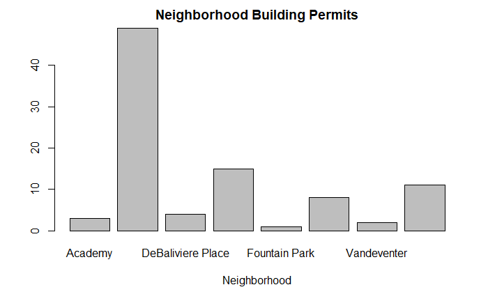

```r
counts <- table(data_month$nbhd_name)
barplot(counts, main = "Neighborhood Building Permits", xlab = "Neighborhood")
```

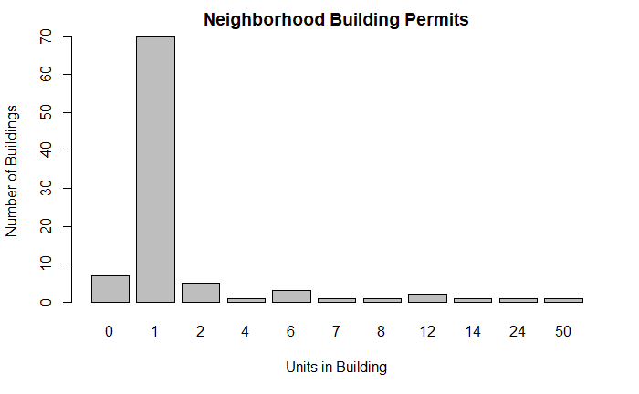

```r
counts <- table(data_month$NbrOfUnits)
barplot(counts, main = "Neighborhood Building Permits", xlab = "Units in Building", ylab = "Number of Buildings")
```

This graph is a count of building permits by ward.

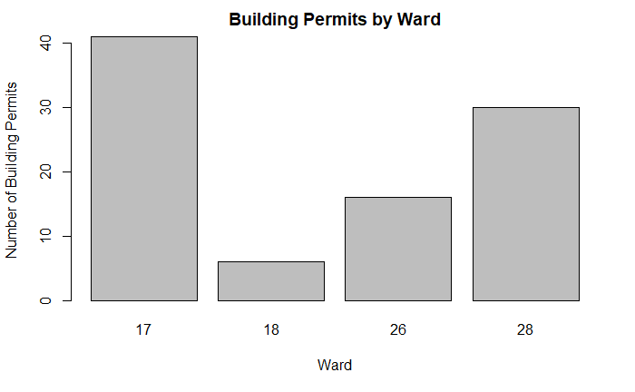

```r
counts <- table(data_month$Ward10)
barplot(counts, main = "Building Permits by Ward", xlab = "Ward", ylab = "Number of Building Permits")
```

###Graph Number of permits by neighborhood and `new_use`

This code chunk uses the `ggplot` function to create a grouped bar chart. Included are arguments to relabel the title, legend, and x and y axes. The `stat` argument is specified as `count` because this displays the number of building permits from the variable `nbhd_name`.

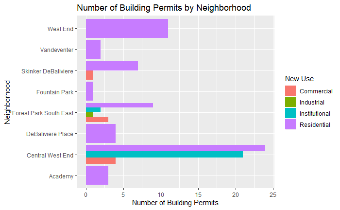

```r
ggplot(data_month, aes(data_month$nbhd_name)) +
  geom_bar(aes(fill = data_month$new_use), position = "dodge", stat="count") +
  ggtitle("Number of Building Permits by Neighborhood") +
  xlab("Neighborhood") +
  ylab("Number of Building Permits") +
  labs(fill = "New Use") +
  coord_flip()
```

###Graph Average Cost by Neighborhood for Each `new_use`

This code uses the `ggplot` function to create a grouped bar plot using the `means` which contains the average building permit cost by neighborhood for each `new_use`. This code also uses `scale_y_continuous` to relabel y-axis tick markers in intervals of one million (1M).

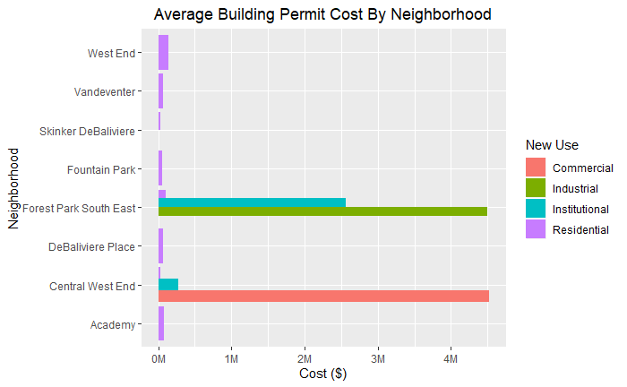

```r
View(means)
ggplot(means, aes(x = nbhd_name, y = mean, fill = new_use)) +
  geom_bar(position = "dodge", stat="identity") +
  ggtitle("Average Building Permit Cost By Neighborhood") +
  theme(plot.title = element_text(hjust = 0.5)) +
  xlab("Neighborhood") +
  ylab("Cost ($)") +
  labs(fill = "New Use") +
  scale_y_continuous(breaks = seq(0, 5000000, by = 1000000), labels = function(y){paste0(y/1000000, 'M')}) +
  coord_flip()
```

Creates a plot that excludes the industrial and institutional cost from Forest Park South east as well as the commercial cost in Central West End. It uses the `scale_y_continuous` command to zoom in on the previous graph while also specifying labels on the y-axis in intervals of 50,000.

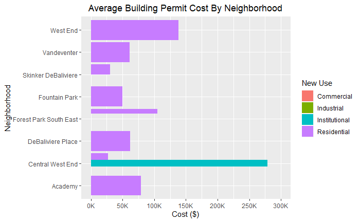

```r
ggplot(means, aes(x = nbhd_name, y = mean, fill = new_use)) +
  geom_bar(position = "dodge", stat="identity") +
  ggtitle("Average Building Permit Cost By Neighborhood") +
  theme(plot.title = element_text(hjust = 0.5)) +
  xlab("Neighborhood") +
  ylab("Cost ($)") +
  labs(fill = "New Use") +
  scale_y_continuous(limits = c(0,300000), breaks = seq(0, 300000, by = 50000), labels = function(y){paste0(y/1000, 'K')}) +
  coord_flip()
```

```r
NA
```

###Plot Building Permits by `high_cost` and `low_cost`

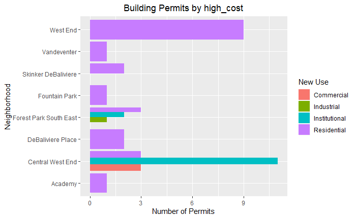

```r
ggplot(means, aes(x = nbhd_name, y = high_cost, fill = new_use)) +
  geom_bar(position = "dodge", stat="identity") +
  ggtitle("Building Permits by high_cost") +
  theme(plot.title = element_text(hjust = 0.5)) +
  xlab("Neighborhood") +
  ylab("Number of Permits") +
  labs(fill = "New Use") +
  coord_flip()
```

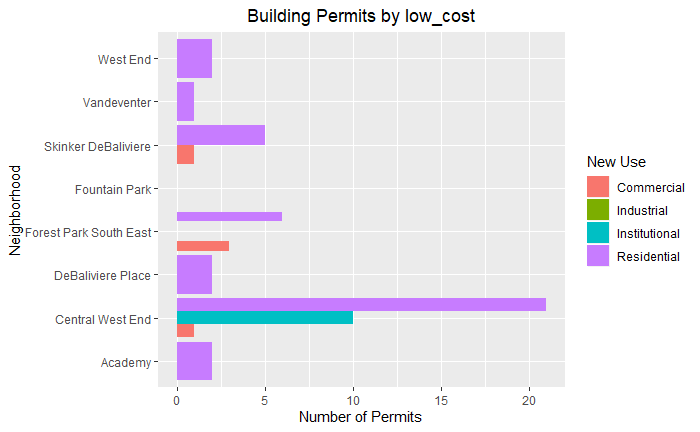

```r
ggplot(means, aes(x = nbhd_name, y = low_cost, fill = new_use)) +
  geom_bar(position = "dodge", stat="identity") +
  ggtitle("Building Permits by low_cost") +
  theme(plot.title = element_text(hjust = 0.5)) +
  xlab("Neighborhood") +
  ylab("Number of Permits") +
  labs(fill = "New Use") +
  coord_flip()
```

### Mapping

I still need to stitch together tiles to create the map image (see mapbox-tiles.R in projects/Safety-Security/r-crime-mapping/src/R).

####The following code needs an API key from google

This code converts the `OrigAddress` variable into a string.

```r
data_month$OrigAddress = as.character(data_month$OrigAddress)
```

One of the options for geocoding the `OrigAddress`

```r
geocode(data_month$OrigAddress, output = c("latlon"), source = ("google"))
```

```
Error: Google now requires an API key.
       See ?register_google for details.
In addition: Warning messages:
1: Unknown or uninitialised column: 'lon'.
2: Unknown or uninitialised column: 'lat'.
3: Unknown or uninitialised column: 'geoAddress'.
```

Another option. The secondn line of code is for actually mapping it (again, needs stitched tiles)

```r
geo_address <- mutate_geocode(data_month, OrigAddress)
qmplot(lon, lat, data = geo_address, colour = I('red'), size = I(3), darken = .3)
```

For loop that is yet another option for geocoding

```r
for(i in 1:nrow(data_month))
{
  # Print("Working...")
  result <- geocode(data_month$OrigAddress[i], output = "latlona", source = "google")
  data_month$lon[i] <- as.numeric(result[1])
  data_month$lat[i] <- as.numeric(result[2])
  data_month$geoAddress[i] <- as.character(result[3])
}
```

### rename handle

```r
data_month %>%
  rename(HANDLE = Handle) -> data_month
```

```r
shape <- shape[!is.na(shape@data$AppType) ,]
```

### merge data into shapefle using HANDLE

```r
shape <- merge(shape, data_month, by="HANDLE", duplicateGeoms = TRUE)
```

### Drop parcels with no permits

```r
shape <- shape[!is.na(shape@data$AppType) ,]
```

## Set WD again to send the shapefile to the correct spot

```r
setwd("G:/Projects/Monthly-Reports/stl-building-permits/monthly-shapefiles")
```

### write shapefile

```r
writeOGR(shape, dsn =".", layer= "permits_MONTH_YEAR1", driver = "ESRI Shapefile")
```